# Optimización de la supervivencia de las colonias de insectos

Sofía Palacios Cuevas, Martín Morales Trejo

Diciembre 07, 2021

## **Introducción**

En este trabajo se utilizarán las ecuaciones diferenciales ordinarias para modelar la propagación / sobrevivencia de las colonias de insectos. El estudio de los ciclos de vida de las colonias ha dado pie a la creencia de que la colonia, aparentemente, maximiza el número de insectos reproductores al final de la temporada. Lo anterior permite que la colonia esparza sus genes, propagando así a los de su tipo en una moda óptima. Pueden considerarse diferentes modelos para el estudio de insectos hibernantes y no hibernantes. Sin embargo, el caso de los no hibernantes es más complejo debio a la necesidad de construir recursos substanciales y colmenas para sobrevivir al invierno.

A constinuación se considerará un modelo para una colinia en la que estudiamos dos tipos de insectos propios de la misma, obreros y reproductores (reinas). Sea $W(t)$ el número de insectos obreros en la colonia al tiempo $t$ (el cual se mide en días de la temporada), mientras que $Q(t)$ corresponde al número de insectos reproductores (reinas) en la colonia al tiempo $t$. Para este estudio, no vamos a suponer ninguna distinción de clase de edad.

Para estudiar las tazas de crecimiento de cada especie, se propone el siguiente modelo:

$\frac{dQ(t)}{dt}=b \cdot c \cdot (1-u(t)) \cdot R(t) \cdot W(t) - v \cdot Q(t) \\ \frac{dW(t)}{dt}=b \cdot u(t) \cdot R(t) \cdot W(t) - \mu \cdot W(t)$

Como condiciones iniciales, usamos $W(0) = 1$ y $Q(0) = 0$ debido a que consideramos a la abeja reina fundadora como una obrera, puesto que ella busca alimento para la primera cría.

Existe también otra población a considerar: los zánganos. Éstos vienen de otras colmenas y son necesarios para fertilizar a las hembras. Una buena colmena durante la temporada de apareamiento puede tener entre 1 - 10 por ciento de zánganos que se reúnen diariamente en nubes que las reinas buscan para ser fecundadas. Las reinas se aparean con 5-20 zánganos y cada zángano muere después del apareamiento. Desafortunadamente, los zánganos no hacen otra cosa que comer miel. No recogen recursos, no defienden, no hacen cera ni cuidan de las crías. Normalmente, todos los zánganos son expulsados de la colmena al final de la temporada. Por lo tanto, en nuestro modelo, no los consideramos.

##### **Descripción de las variables:**

[output not shown]

Otro factor es el inventario de miel. Cuando hay mucha, las abejas empiezan a cambiar de comportamiento. Se preparan para un enjambre y crían más abejas. Así que tal vez también se podría incluir un “Inventario” de recursos que se añade con los recursos disponibles de fuera de la colonia. Tal vez haya un umbral de inventario por encima del cual el comportamiento cambia. Otro factor es que un enjambre necesita suficientes abejas y miel para empezar una nueva colonia con éxito y dejar suficientes abejas (y crías) para ser viable. Una estimación aproximada es que el 50% de las abejas se van en un enjambre y el buen tamaño de la colonia antes de un enjambre es de unas 50.000 abejas. Aquí hay mucha variación.

Ahora la pregunta es la siguiente,

“¿Qué $u(t)$ debe utilizar la colonia para que el número de reproductores, $Q(T)$, al final de la temporada (cuando $t = T$) sea máximo?”

La determinación de esta función $u(t)$ pertenece a una disciplina conocida como teoría del control óptimo. Se trata de una clase de problemas que tratan de encontrar el valor de T de forma que se optimice algún valor funcional, en este caso $Q(T)$, mientras está sujeto a algún sistema dinámico, en este caso las ecuaciones diferenciales $(1)$ con condiciones iniciales.

Consideremos estos valores de los parámetros: $b = 0.0013$, $c = 1$, $\mu= 0.022$, $v = 0.005$, $T = 205$ días y $R(t) = 50$. Recordemos que $u(t)$ es una función (en este caso, llamada función de control admisible, en realidad) que está entre 0 y 1, donde $u(t) = 0$, significa que en el tiempo $t$ la colonia pone el 0% de sus energías en la producción de obreras; $u(t) = 1$, significa que en el tiempo $t$ la colonia pone el $100%$ de sus energías en la producción de obreras; y, por ejemplo, $u(140) = 0.31$, significa que en el tiempo $t= 140$ la colonia pone el $31%$ de sus energías en la producción de obreras.

## **Metodología**

Se pasa de no criar ninguna reina a criar unas pocas. Sin embargo, hay demasiadas abejas para que dediquen toda su energía a criar reinas. Sólo se necesitan unas pocas abejas para criar reinas, digamos de 5 a 100 de 50.000. Probablemente se deba a la velocidad a la que una obrera puede producir jalea real y a la cantidad que necesita una reina. El resto de las abejas se ocupan de recoger más néctar, fabricar celdas de cera, rechazar a los intrusos, recoger polen, limpiar la colmena, etc. Así, otro modelo podría considerar que hay dos niveles de $u(t)$: bajo $(u(t) = 0)$ y alto $(u(t)0.0001\cdot W)$. Puede ser que la energía para hacer una reina no sea un gran problema. Tiene que ver más con el número de abejas, el inventario de miel, el inventario de crías, los niveles de recursos naturales, la temporada (se necesitan muchos zánganos de otras colmenas), la temperatura, etc. Ahora, ¿podemos determinar un tiempo de cambio óptimo t, cuando la colonia debe pasar de producir todos los insectos obreros $(u(t) = 1$ para $t< t_{s}$, por lo que $u(t) = 1 - UnitStep[t -t_{s}])$ a producir todos los reproductores (reinas) $(u(t) = 0$ para $t> t_{s})$?

## **Resultados**

De las $u(t)$ propuestas, se obtuvieron las siguientes gráficas al evaluar las funciones en el intervalo $t = [0, 205]$:

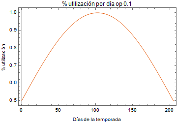

$u_{1}$

En la Figura 1 la función $u(t) = 0.5 + 0.5 sin(\frac{\pi}{205}t)$ se comporta parabólicamente, proponiendo que para la mitad de la temporada, la colonia ya ha utilizado el 100 % de los recursos. Luego, el procentaje de consumo va a la baja en lo que resta de la temporada.

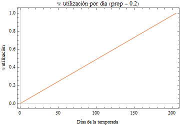

$u_{2}$

Mientras tanto, en la Figura 2 la utilización de recursos, resultado de la función $u_{2}(t)$, sigue un comportamiento lineal, tendiendo a aumentar el uso de recursos conforme avanza la temporada.

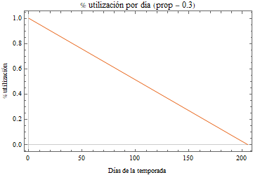

$u_{3}$

Finalmente, en la Figura 3 observamos que la colonia hace uso del 100 % de los recursos desde el principio, decrementando el porcentaje de utilización conforme avanza la temporada. Este comportamiento ha sido planteado por la función $u_{3}(t)$.

Para cada $u(t)$ se obtuvieron las siguientes gráficas de $W(t)$ y $Q(t)$ en el intervalo de tiempo $t = [0, 205]$:

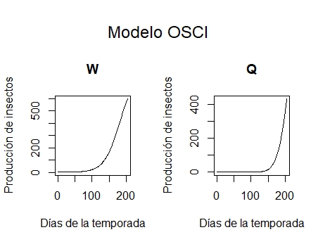

Modelo OSCI con $u_{1}$

Utilizando $u_{1}(t)$ en las soluciones de las ecuaciones propuestas $(1)$ y evaluando dichas soluciones en el intervalo de tiempo $t =[0,205]$ obtenemos las gráficas que se presentan en la figura 4. Notemos que el número de abejas obreras empieza a crecer aproximadamente a los 75 días de haber iniciado la temporada. Por otro lado, la producción de abejas reina comienza cerca del día 125 de la temporada. Por último, las gráficas muestran que la producción diaria de insectos obreras es mayor que la de insectos reina.

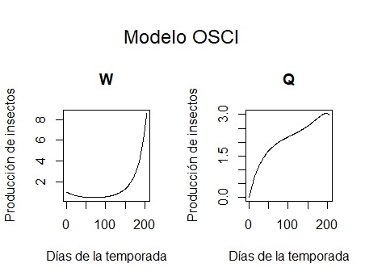

Modelo OSCI con $u_{2}$

De forma contrastante, la figura 5 presenta comportamientos muy diferentes para la producción de los insectos obrera y reina. Primeramente, la producción de obreras deciende en los primeros 50 días, luego se mantiene constante y finalmente empieza a crecer a partir del día 100. Por el contrario, la producción de insectos reina siempre va aumentando, aunque a diferentes ritmos.

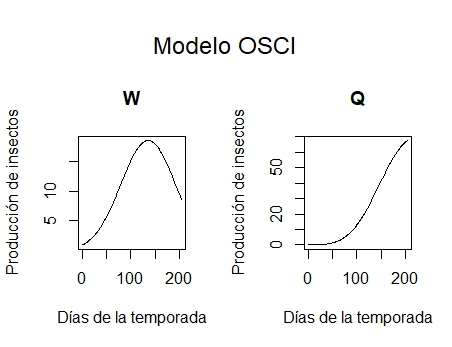

Modelo OSCI con $u_{3}$

## **Referencias**

- Soeteart, K., Petzoldt, T., Setzer, W. (2010). *Package deSolve: Solving Intial Value Differential Equations in R* Recuperado el 08 de Diciembre, de sitio web: https://cran.r-project.org/web/packages/deSolve/vignettes/deSolve.pdf